# 🧠 Learning About Brain-Inspired Networks!

## A Kid-Friendly Guide to Hopfield Networks

Hello there! Today we're going to learn about something really cool called a **Hopfield Network**. Think of it like a tiny artificial brain that can remember patterns. We'll create a simple one and see how it works!

### 📚 First, Let's Get Our Tools Ready

Just like how you need crayons and paper to draw, we need some special tools to create our network.

```python
# Import our special tools
import numpy as np        # This helps us work with numbers
import matplotlib.pyplot as plt  # This helps us make pretty pictures

print("Yay! Our tools are ready! 🎉")
```

```
Yay! Our tools are ready! 🎉
```

### 🤔 What is a Hopfield Network?

Imagine you have two friends who like to match their moods:

- When one is happy, the other tends to be happy too
- When one is sad, the other tends to be sad too

Our network works the same way! We'll have two "neurons" (like tiny brain cells) that can be either:

- Happy (+1) 😊
- Sad (-1) 😢

### 🔧 Let's Create Our Helper Function

This function will help us measure how "comfortable" our network feels in different states.

```python
def calculate_network_energy(weights, states):
    """
    This is like a happiness meter for our network!
    - Lower energy = more comfortable 😊
    - Higher energy = less comfortable 😟
    """
    energy = -0.5 * np.sum(np.dot(states, weights) * states)
    return energy
```

### 🎨 Now Let's Create Our Main Function to Draw the Picture!

This function will show us all the possible ways our two neurons can feel and how comfortable the network is with each combination.

```python
def create_energy_landscape():
    """
    Let's make a colorful map of our network's favorite states!
    Blue means the network is very comfortable, red means it's uncomfortable.
    """
    # Step 1: Set up our network
    # This tells us how strongly our neurons are connected
    weights = np.array([
        [0, 1],  # First neuron's connections
        [1, 0]   # Second neuron's connections
    ])

    # Step 2: Define possible moods
    possible_states = np.array([-1, 1])  # Sad (-1) or Happy (+1)

    # Step 3: Create all possible mood combinations
    state1, state2 = np.meshgrid(possible_states, possible_states)

    # Step 4: Calculate how comfortable each combination is
    energy_map = np.zeros(state1.shape)

    for i in range(state1.shape[0]):
        for j in range(state1.shape[1]):
            current_state = np.array([state1[i, j], state2[i, j]])
            energy_map[i, j] = calculate_network_energy(weights, current_state)

    # Step 5: Draw our colorful map!
    plt.figure(figsize=(12, 8))

    # Create the main plot with nice colors
    contour = plt.contourf(state1, state2, energy_map, levels=50,
                          cmap='RdYlBu_r')

    # Add a color guide
    colorbar = plt.colorbar(contour)
    colorbar.set_label('Comfort Level\n(Blue = Very Comfortable)',
                      rotation=270, labelpad=15)

    # Make it pretty!
    plt.title('Our Network\'s Favorite States! 🎯',
              fontsize=16, pad=20)
    plt.xlabel('First Neuron\'s Mood 😊', fontsize=14)
    plt.ylabel('Second Neuron\'s Mood 😊', fontsize=14)

    # Label the points clearly
    plt.xticks(ticks=[-1, 1], labels=['Sad 😢', 'Happy 😊'])
    plt.yticks(ticks=[-1, 1], labels=['Sad 😢', 'Happy 😊'])

    # Add helpful grid lines
    plt.grid(True, linestyle='--', alpha=0.7)

    # Add a fun explanation box
    explanation = """
    📖 What are we looking at?

    • BLUE areas = The network is super comfortable!
      Both neurons agree with each other.

    • RED areas = The network is uncomfortable!
      The neurons disagree with each other.

    • The network is happiest when both neurons
      feel the same way (both happy or both sad)!
    """
    plt.text(1.5, 0, explanation,
            bbox=dict(facecolor='white', alpha=0.8, edgecolor='gray'),
            fontsize=12)

    plt.tight_layout()
    plt.show()
```

### 🚀 Let's Run Our Code and See What Happens!

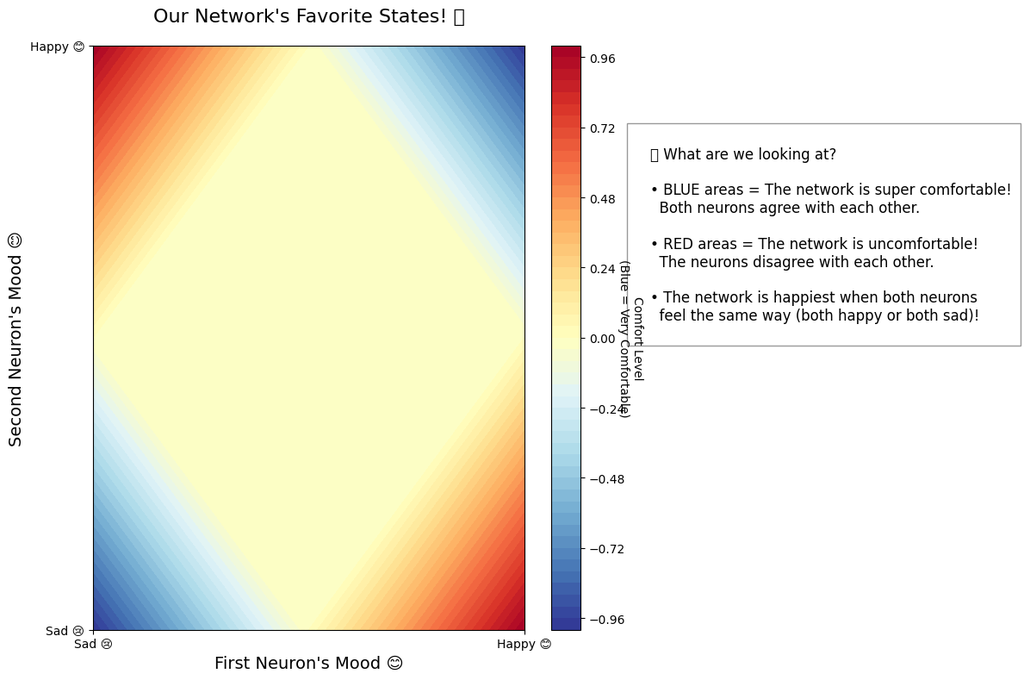

```python
# Time to make our visualization!
create_energy_landscape()
```

### 🎯 Understanding What We See

Let's break down what our picture shows:

1. **The Blue Areas** 🔵
   - These show when our network is most comfortable
   - This happens when both neurons agree (both happy or both sad)
2. **The Red Areas** 🔴
   - These show when our network is uncomfortable
   - This happens when our neurons disagree (one happy, one sad)
3. **What This Means** 💡
   - Our network likes harmony! Just like real friends, our neurons prefer to be in the same mood
   - This is why the corners where both neurons match (both +1 or both -1) are blue
   - The other corners where they disagree are red

### 🤓 Fun Facts!

- This is similar to how real brain cells work together
- Scientists use these networks to study memory and learning
- The blue areas are like memories that the network wants to remember

### 🎮 Try It Yourself!

Here are some fun things you can try:

1. What happens if you change the weights in the network?
2. Can you predict which corners will be blue before running the code?
3. Try counting how many stable states (blue areas) our network has!

### 🌟 Congratulations!

You've just learned about:

- How simple brain-like networks work
- How neurons can work together
- How to visualize network states

Keep exploring and learning! 🚀